🏠 Inicio del curso | 📈 Optimización de portafolios (PyPortfolioOpt)

# Optimización de portafolios

En esta sesion vamos a estudiar como se realiza la optimizacion de portafolios.

```python
# Instalación de librerías no disponibles en Colab

# !pip install --quiet PyPortfoliopt CVXPY ffn
```

```python
import warnings
warnings.filterwarnings("ignore")

import numpy as np
import pandas as pd
import yfinance as yf
import matplotlib.pyplot as plt
import seaborn as sns
import ffn
import re

from pypfopt import EfficientFrontier, risk_models, expected_returns, plotting
from pypfopt import objective_functions
```

Definamos nuestros parametros iniciales

```python
empresas = pd.read_csv(filepath_or_buffer = "https://raw.githubusercontent.com/salas317/Data/main/NASDAQ_NYSE.csv",
                       parse_dates = ["IPO Date"],
                       dayfirst = True)
acciones = empresas["Ticker Symbol"][0:21].to_list()
acciones = [re.sub(pattern = r"[\.\ ]", repl = "-", string = accion) for accion in acciones]
inicio = "2020-12-31"
fin = "2026-10-20"
rf_annual = 0.119
```

```python
precios = yf.download(tickers = acciones,
                      start = inicio,
                      end = fin,
                      auto_adjust = False,
                      progress = False)
precios = precios["Adj Close"]
```

Ahora estimemos los insumos que vamos a necesitar en el proceso de optimizacion.

```python
# Retornos medios historicos anualizados
mu = expected_returns.mean_historical_return(prices = precios,
                                             returns_data = False,
                                             compounding = False,
                                             frequency = 252,
                                             log_returns = True)

# Tambien puede calcularse la EMA

mue = expected_returns.ema_historical_return(prices = precios,
                                             returns_data = False,
                                             compounding = False,
                                             frequency = 252,
                                             log_returns = True,
                                             span = 180) # Ventana de tiempo para el cálculo de la EMA
```

```python
# Matriz de varianzas y covarianzas anualizadas
S = risk_models.sample_cov(prices = precios,
                           returns_data = False,
                           frequency = 252,
                           log_returns = True)

# Igual se pueden usar ventanas moviles exponenciales

Se= risk_models.exp_cov(prices = precios,
                        returns_data = False,
                        frequency = 252,
                        log_returns = True,
                        span = 180) # Ventana de tiempo para el cálculo de la matriz de covarianzas exponencial
```

```python
retornos = expected_returns.returns_from_prices(prices = precios,
                                                log_returns = True)
```

## Portafolio clásico de media varianza con largos

Vamos a trabajar inicialmente un portafolio que tiene la siguiente forma:

$$ \begin{aligned} \text{minimizar}_w \quad & w^T \Sigma w \\ \text{sujeto a:} \quad & w^T\mu \geq \mu^*\\ & w^T \mathbf{1} = 1 \\ & w_i \geq 0 \quad \forall i \end{aligned} $$

Primero, vamos a definir el objeto del portafolio, usando el vector de medias y la matriz de varianza y covarianzas que acabamos de calcular. Ademas, vamos a permitir que el pesos asignado a los diferentes activos se encuentre entre el 0% y el 100%.

```python
# Definimos un objeto de clase EfficientFrontier
ef_long = EfficientFrontier(expected_returns = mu,
                            cov_matrix = S,
                            weight_bounds = (0, 1))
```

Ahora, construyamos nuestra frontera eficiente para este problema de optimización.

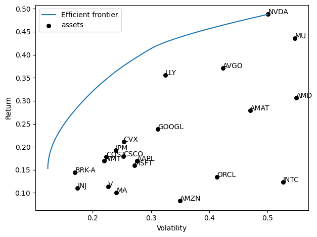

```python
# Grafiquemos la frontera eficiente de este conjunto de portafolios
fig, ax = plt.subplots()
plotting.plot_efficient_frontier(ef_long,
                                 ax=ax,
                                 show_assets = True,
                                 show_tickers = True,
                                 points = 1000)
plt.show()
```

Viendo la frontera, ya sabemos que el portafolio que maximiza el retorno es invertir todo nuestro capital en acciones de Nvidia. Miremos cual es el retorno esperado y el riesgo de este portafolio.

```python
print(f"El retorno medio anualizado de Nvidia es de {mu["NVDA"]:.4%}")

print(f"La volatilidad anualizada de Nvidia es de {S["NVDA"]["NVDA"]**(1/2):.4%}")
```

```
El retorno medio anualizado de Nvidia es de 48.7769%
La volatilidad anualizada de Nvidia es de 50.0673%
```

### Portafolio que minimiza el riesgo

Ahora, vamos a hallar el portafolio que minimiza el riesgo.

```python
# Definimos un objeto de clase EfficientFrontier
ef_min_risk = EfficientFrontier(expected_returns = mu,
                            cov_matrix = S,
                            weight_bounds = (0, 1))
```

```python
p_min_risk = ef_min_risk.min_volatility() # Permite hallar el portafolio de mínima volatilidad
w_min_risk = ef_min_risk.clean_weights() # Extraemos los pesos del portafolio
print("Pesos del portafolio de mínima volatilidad:")
w_min_risk
```

```
Pesos del portafolio de mínima volatilidad:
```

```
OrderedDict([('AAPL', 0.0),
             ('AMAT', 0.0),
             ('AMD', 0.0),
             ('AMZN', 0.0),
             ('AVGO', 0.01673),
             ('BRK-A', 0.17603),
             ('COST', 0.02201),
             ('CSCO', 0.04179),
             ('CVX', 0.10614),
             ('GOOGL', 0.00475),
             ('INTC', 0.0),
             ('JNJ', 0.35431),
             ('JPM', 0.0),
             ('LLY', 0.0103),
             ('MA', 0.0),
             ('MSFT', 0.07069),
             ('MU', 0.0073),
             ('NVDA', 0.0),
             ('ORCL', 0.02936),
             ('V', 0.03283),
             ('WMT', 0.12778)])
```

```python
perf_min_risk = ef_min_risk.portfolio_performance(verbose = True) # Considerando que no hay tasa libre de riesgo
```

```
Expected annual return: 15.3%
Annual volatility: 12.3%
Sharpe Ratio: 1.24
```

```python
perf_min_risk = ef_min_risk.portfolio_performance(verbose = True, risk_free_rate = rf_annual)
```

```
Expected annual return: 15.3%
Annual volatility: 12.3%
Sharpe Ratio: 0.28
```

### Portafolio que maximiza el retorno para un riesgo dado

Ahora, encontremos el portafolio que maximiza el retorno si queremos tener un riesgo del 35%

```python
# Definimos un objeto de clase EfficientFrontier
ef_risk = EfficientFrontier(expected_returns = mu,
                            cov_matrix = S,
                            weight_bounds = (0, 1))
```

```python
p_risk = ef_risk.efficient_risk(target_volatility = 0.35) # Permite hallar el portafolio de mínima volatilidad
w_risk = ef_risk.clean_weights() # Extraemos los pesos del portafolio
print("Pesos del portafolio que maximiza el retorno para una volatilidad del 35%:")
w_risk
```

```
Pesos del portafolio que maximiza el retorno para una volatilidad del 35%:
```

```
OrderedDict([('AAPL', 0.0),
             ('AMAT', 0.0),
             ('AMD', 0.0),
             ('AMZN', 0.0),
             ('AVGO', 0.0),
             ('BRK-A', 0.0),
             ('COST', 0.0),
             ('CSCO', 0.0),
             ('CVX', 0.0),
             ('GOOGL', 0.0),
             ('INTC', 0.0),
             ('JNJ', 0.0),
             ('JPM', 0.0),
             ('LLY', 0.33249),
             ('MA', 0.0),
             ('MSFT', 0.0),
             ('MU', 0.10035),
             ('NVDA', 0.56717),
             ('ORCL', 0.0),
             ('V', 0.0),
             ('WMT', 0.0)])
```

```python
perf_risk = ef_risk.portfolio_performance(verbose = True) # Considerando que no hay tasa libre de riesgo
```

```
Expected annual return: 43.8%
Annual volatility: 35.0%
Sharpe Ratio: 1.25
```

```python
perf_risk = ef_risk.portfolio_performance(verbose = True, risk_free_rate = rf_annual) # Considerando una tasa libre de riesgo anual del 5%
```

```
Expected annual return: 43.8%
Annual volatility: 35.0%
Sharpe Ratio: 0.91
```

### Portafolio que minimiza el riesgo para un retorno dado

```python
# Definimos un objeto de clase EfficientFrontier
ef_return = EfficientFrontier(expected_returns = mu,
                            cov_matrix = S,
                            weight_bounds = (0, 1))
```

```python
p_return = ef_return.efficient_return(target_return = 0.30) # Permite hallar el portafolio de mínima volatilidad
w_return = ef_return.clean_weights() # Extraemos los pesos del portafolio
print("Pesos del portafolio que minimiza el riesgo para un rendimiento del 30%:")
w_return
```

```
Pesos del portafolio que minimiza el riesgo para un rendimiento del 30%:
```

```
OrderedDict([('AAPL', 0.0),
             ('AMAT', 0.0),
             ('AMD', 0.0),
             ('AMZN', 0.0),
             ('AVGO', 0.05996),
             ('BRK-A', 0.0),
             ('COST', 0.0),
             ('CSCO', 0.0),
             ('CVX', 0.24277),
             ('GOOGL', 0.0),
             ('INTC', 0.0),
             ('JNJ', 0.04655),
             ('JPM', 0.01),
             ('LLY', 0.30549),
             ('MA', 0.0),
             ('MSFT', 0.0),
             ('MU', 0.05812),
             ('NVDA', 0.12155),
             ('ORCL', 0.0),
             ('V', 0.0),
             ('WMT', 0.15556)])
```

```python
perf_return = ef_return.portfolio_performance(verbose = True) # Considerando que no hay tasa libre de riesgo
```

```
Expected annual return: 30.0%
Annual volatility: 18.4%
Sharpe Ratio: 1.63
```

```python
perf_return = ef_return.portfolio_performance(verbose = True, risk_free_rate = rf_annual) # Considerando una tasa libre de riesgo anual del 5%
```

```
Expected annual return: 30.0%
Annual volatility: 18.4%
Sharpe Ratio: 0.98
```

### Portafolio que maximiza el ratio de sharpe

Ahora, encontremos el portafolio que maximiza el ratio de sharpe

```python
# Definimos un objeto de clase EfficientFrontier
ef_sharpe = EfficientFrontier(expected_returns = mu,
                            cov_matrix = S,
                            weight_bounds = (0, 1))
```

```python
p_sharpe = ef_sharpe.max_sharpe() # Maximizar el ratio de Sharpe sin contar con la tasa libre de riesgo
w_sharpe = ef_sharpe.clean_weights() # Extraemos los pesos del portafolio
print("Pesos del portafolio que maximiza el ratio de Sharpe:")
w_sharpe
```

```
Pesos del portafolio que maximiza el ratio de Sharpe:
```

```
OrderedDict([('AAPL', 0.0),
             ('AMAT', 0.0),
             ('AMD', 0.0),
             ('AMZN', 0.0),
             ('AVGO', 0.05685),
             ('BRK-A', 0.01973),
             ('COST', 0.0),
             ('CSCO', 0.0),
             ('CVX', 0.21138),
             ('GOOGL', 0.01611),
             ('INTC', 0.0),
             ('JNJ', 0.15613),
             ('JPM', 0.02659),
             ('LLY', 0.22137),
             ('MA', 0.0),
             ('MSFT', 0.0),
             ('MU', 0.04433),
             ('NVDA', 0.08576),
             ('ORCL', 0.0),
             ('V', 0.0),
             ('WMT', 0.16175)])
```

```python
perf_sharpe = ef_sharpe.portfolio_performance(verbose = True) # Considerando que no hay tasa libre de riesgo
```

```
Expected annual return: 26.2%
Annual volatility: 15.8%
Sharpe Ratio: 1.66
```

### Portafolio que maximiza el ratio de sharpe con una tasa libre de riesgo (CML)

Ahora, encontremos el portafolio que maximiza el ratio de sharpe considerando una tasa libre de riesgo. Lo que nos permite construir nuestra linea de mercado de capitales (CML)

```python
# Definimos un objeto de clase EfficientFrontier
ef_cml = EfficientFrontier(expected_returns = mu,
                            cov_matrix = S,
                            weight_bounds = (0, 1))
```

```python
p_cml = ef_cml.max_sharpe(risk_free_rate = rf_annual) # Maximizar el ratio de Sharpe para la tasa libre de riesgo anual del 5%
w_cml = ef_cml.clean_weights() # Extraemos los pesos del portafolio
print("Pesos del portafolio que maximiza el ratio de Sharpe:")
w_cml
```

```
Pesos del portafolio que maximiza el ratio de Sharpe:
```

```
OrderedDict([('AAPL', 0.0),
             ('AMAT', 0.0),
             ('AMD', 0.0),
             ('AMZN', 0.0),
             ('AVGO', 0.05474),
             ('BRK-A', 0.0),
             ('COST', 0.0),
             ('CSCO', 0.0),
             ('CVX', 0.22056),
             ('GOOGL', 0.0),
             ('INTC', 0.0),
             ('JNJ', 0.0),
             ('JPM', 0.0),
             ('LLY', 0.42443),
             ('MA', 0.0),
             ('MSFT', 0.0),
             ('MU', 0.08098),
             ('NVDA', 0.19847),
             ('ORCL', 0.0),
             ('V', 0.0),
             ('WMT', 0.02081)])
```

```python
perf_cml = ef_cml.portfolio_performance(verbose = True, risk_free_rate = rf_annual) # Considerando una tasa libre de riesgo anual del 5%
```

```
Expected annual return: 35.3%
Annual volatility: 22.9%
Sharpe Ratio: 1.02
```

Para este último portafolio vamos a graficar los pesos asignado a cada uno de los activos.

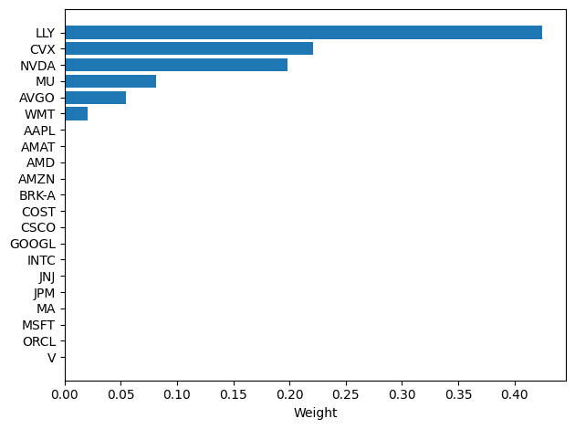

```python
plotting.plot_weights(w_cml)
plt.show()
```

## Gráfico resumen

Vamos a crear un gráfico que resume varios de los resultados obtenidos.

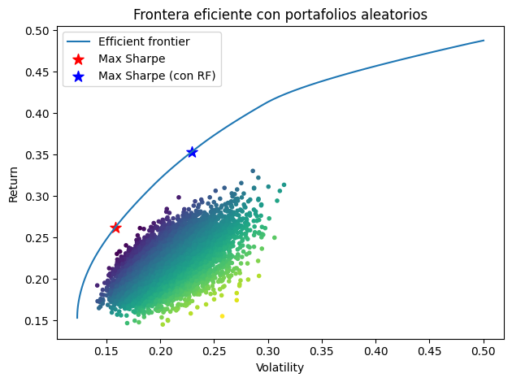

```python
fig, ax = plt.subplots()
ef_plot = EfficientFrontier(expected_returns = mu,
                            cov_matrix = S,
                            weight_bounds = (0, 1))
plotting.plot_efficient_frontier(ef_plot,
                                 ax=ax,
                                 show_assets=False)

# Mostrar el portafolio con maximo ratio de Sharpe
ret_tangent, std_tangent, _ = perf_sharpe
ax.scatter(std_tangent, ret_tangent, marker="*", s=100, c="r", label="Max Sharpe")

# Mostra mos el portafolio con maximo ratio de Sharpe considerando la tasa libre de riesgo
ret_cml, std_cml, _ = perf_cml
ax.scatter(std_cml, ret_cml, marker="*", s=100, c="b", label="Max Sharpe (con RF)")

# Generacion de portafolios aleatorios
n_samples = 10000
w = np.random.dirichlet(np.ones(ef_plot.n_assets), n_samples)
rets = w.dot(ef_plot.expected_returns)
stds = np.sqrt(np.diag(w @ ef_plot.cov_matrix @ w.T))
sharpes = rets / stds
ax.scatter(stds, rets, marker=".", c=sharpes, cmap="viridis_r")

ax.set_title("Frontera eficiente con portafolios aleatorios")
ax.legend()
plt.tight_layout()
plt.show()
```

## Optimización considerando ventas en corto

Consideremos ahora el mismo problema inicial. Pero, vamos a permitir las ventas en corto, limitando cada activo a un peso de -20%.

$$ \begin{aligned} \text{minimizar}_w \quad & w^T \Sigma w \\ \text{sujeto a:} \quad & w^T\mu \geq \mu^*\\ & w^T \mathbf{1} = 1 \\ & w_i \geq -0.2 \quad \forall i \end{aligned} $$

```python
# Definimos un objeto de clase EfficientFrontier
ef_short = EfficientFrontier(expected_returns = mu,
                            cov_matrix = S,
                            weight_bounds = (-0.2, 1))
```

Ahora, construyamos nuestra frontera eficiente para este problema de optimización.

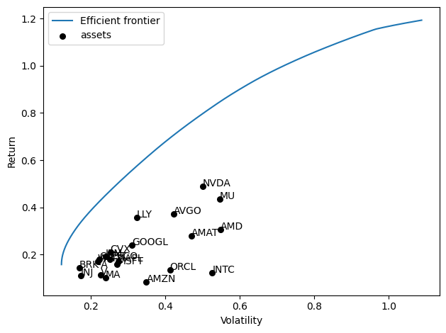

```python
# Grafiquemos la frontera eficiente de este conjunto de portafolios
fig, ax = plt.subplots()
plotting.plot_efficient_frontier(ef_short,
                                 ax=ax,
                                 show_assets = True,
                                 show_tickers = True,
                                 points = 1000)
plt.show()
```

Miremos cual portafolio maximiza el retorno esperado del portafolio.

```python
# Definimos un objeto de clase EfficientFrontier
ef_risk_short = EfficientFrontier(expected_returns = mu,
                            cov_matrix = S,
                            weight_bounds = (-0.2, 1))
```

```python
p_risk_short = ef_risk_short.efficient_risk(target_volatility = 1.1)
w_risk_short = ef_risk_short.clean_weights() # Extraemos los pesos del portafolio
print("Pesos del portafolio que maximiza el retorno:")
w_risk_short
```

```
Pesos del portafolio que maximiza el retorno:
```

```
OrderedDict([('AAPL', -0.2),
             ('AMAT', -0.2),
             ('AMD', 0.2),
             ('AMZN', -0.2),
             ('AVGO', 1.0),
             ('BRK-A', -0.2),
             ('COST', -0.2),
             ('CSCO', -0.2),
             ('CVX', -0.2),
             ('GOOGL', -0.2),
             ('INTC', -0.2),
             ('JNJ', -0.2),
             ('JPM', -0.2),
             ('LLY', 1.0),
             ('MA', -0.2),
             ('MSFT', -0.2),
             ('MU', 1.0),
             ('NVDA', 1.0),
             ('ORCL', -0.2),
             ('V', -0.2),
             ('WMT', -0.2)])
```

```python
perf_risk_short = ef_risk_short.portfolio_performance(verbose = True) # Considerando que no hay tasa libre de riesgo
```

```
Expected annual return: 119.4%
Annual volatility: 108.8%
Sharpe Ratio: 1.10
```

```python
perf_risk_short = ef_risk_short.portfolio_performance(verbose = True, risk_free_rate = rf_annual) # Considerando una tasa libre de riesgo anual del 5%
```

```
Expected annual return: 119.4%
Annual volatility: 108.8%
Sharpe Ratio: 0.99
```

Miremos cual es el portafolio que maximiza el ratio de sharpe

```python
# Definimos un objeto de clase EfficientFrontier
ef_cml_short = EfficientFrontier(expected_returns = mu,
                            cov_matrix = S,
                            weight_bounds = (-0.2, 1))
```

```python
p_cml_short = ef_cml_short.max_sharpe(risk_free_rate = rf_annual) # Maximizar el ratio de Sharpe para la tasa libre de riesgo anual del 5%
w_cml_short = ef_cml_short.clean_weights() # Extraemos los pesos del portafolio
print("Pesos del portafolio que maximiza el ratio de Sharpe:")
w_cml_short
```

```
Pesos del portafolio que maximiza el ratio de Sharpe:
```

```
OrderedDict([('AAPL', -0.19638),
             ('AMAT', -0.2),
             ('AMD', -0.06836),
             ('AMZN', -0.2),
             ('AVGO', 0.22108),
             ('BRK-A', 0.06963),
             ('COST', 0.06242),
             ('CSCO', 0.07232),
             ('CVX', 0.37351),
             ('GOOGL', 0.24856),
             ('INTC', -0.16742),
             ('JNJ', -0.10842),
             ('JPM', 0.17494),
             ('LLY', 0.52825),
             ('MA', -0.2),
             ('MSFT', -0.09688),
             ('MU', 0.25609),
             ('NVDA', 0.39016),
             ('ORCL', -0.2),
             ('V', -0.17248),
             ('WMT', 0.213)])
```

```python
perf_cml_short = ef_cml_short.portfolio_performance(verbose = True, risk_free_rate = rf_annual) # Considerando una tasa libre de riesgo anual del 5%
```

```
Expected annual return: 57.2%
Annual volatility: 32.2%
Sharpe Ratio: 1.41
```

Para este último portafolio vamos a graficar los pesos asignado a cada uno de los activos.

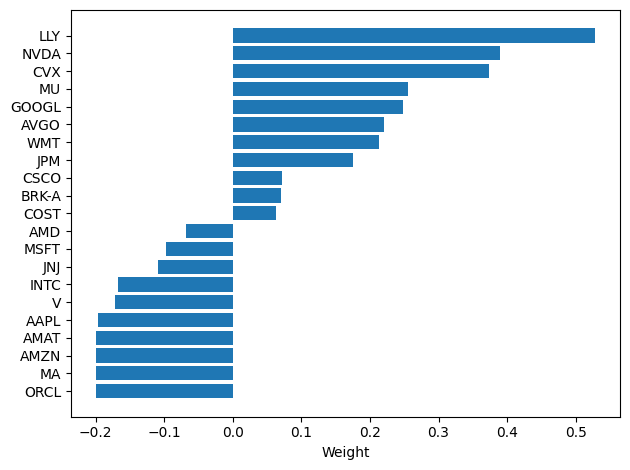

```python
plotting.plot_weights(w_cml_short)
plt.show()
```

### Gráfico resumen

Vamos a crear un gráfico que resume varios de los resultados obtenidos.

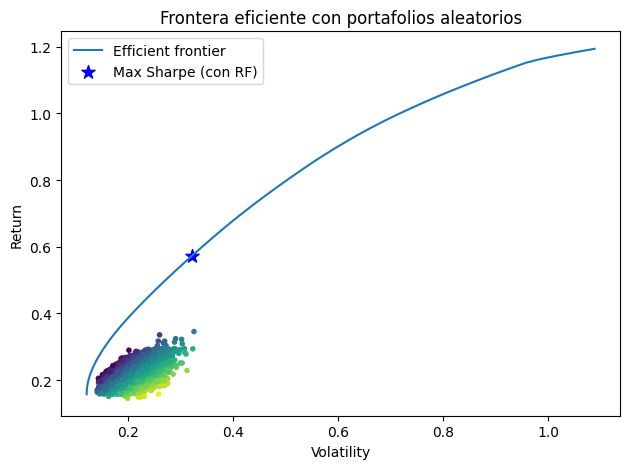

```python
fig, ax = plt.subplots()
ef_plot_short = EfficientFrontier(expected_returns = mu,
                            cov_matrix = S,
                            weight_bounds = (-0.2, 1))
plotting.plot_efficient_frontier(ef_plot_short,
                                 ax=ax,
                                 show_assets=False)

# Mostra mos el portafolio con maximo ratio de Sharpe considerando la tasa libre de riesgo
ret_cml, std_cml, _ = perf_cml_short
ax.scatter(std_cml, ret_cml, marker="*", s=100, c="b", label="Max Sharpe (con RF)")

# Generacion de portafolios aleatorios
n_samples = 10000
w = np.random.dirichlet(np.ones(ef_plot.n_assets), n_samples)
rets = w.dot(ef_plot.expected_returns)
stds = np.sqrt(np.diag(w @ ef_plot.cov_matrix @ w.T))
sharpes = rets / stds
ax.scatter(stds, rets, marker=".", c=sharpes, cmap="viridis_r")

ax.set_title("Frontera eficiente con portafolios aleatorios")
ax.legend()
plt.tight_layout()
plt.show()
```

## Optimización considerando una mayor diversificación (permitiendo posiciones cortas)

```python
# Definimos un objeto de clase EfficientFrontier
ef_cml_diver = EfficientFrontier(expected_returns = mu,
                            cov_matrix = S,
                            weight_bounds = (-0.1, 0.35))
```

```python
p_cml_diver = ef_cml_diver.max_sharpe(risk_free_rate = rf_annual) # Maximizar el ratio de Sharpe para la tasa libre de riesgo anual del 5%
w_cml_diver = ef_cml_diver.clean_weights() # Extraemos los pesos del portafolio
print("Pesos del portafolio que maximiza el ratio de Sharpe:")
w_cml_diver
```

```
Pesos del portafolio que maximiza el ratio de Sharpe:
```

```
OrderedDict([('AAPL', -0.1),
             ('AMAT', -0.1),
             ('AMD', -0.08318),
             ('AMZN', -0.1),
             ('AVGO', 0.15483),
             ('BRK-A', 0.03724),
             ('COST', 0.03008),
             ('CSCO', 0.03084),
             ('CVX', 0.31199),
             ('GOOGL', 0.15936),
             ('INTC', -0.1),
             ('JNJ', 0.02042),
             ('JPM', 0.10939),
             ('LLY', 0.35),
             ('MA', -0.1),
             ('MSFT', -0.1),
             ('MU', 0.17761),
             ('NVDA', 0.29519),
             ('ORCL', -0.1),
             ('V', -0.1),
             ('WMT', 0.20624)])
```

```python
perf_cml_diver = ef_cml_diver.portfolio_performance(verbose = True, risk_free_rate = rf_annual) # Considerando una tasa libre de riesgo anual del 5%
```

```
Expected annual return: 44.0%
Annual volatility: 24.3%
Sharpe Ratio: 1.32
```

Para este último portafolio vamos a graficar los pesos asignado a cada uno de los activos.

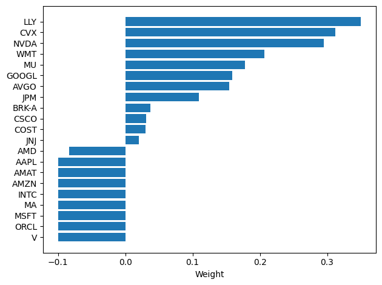

```python
plotting.plot_weights(w_cml_diver)
plt.show()
```

### Gráfico resumen

Vamos a crear un gráfico que resume varios de los resultados obtenidos.

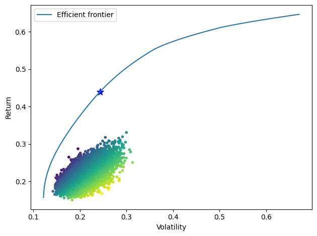

```python
fig, ax = plt.subplots()
ef_plot_diver = EfficientFrontier(expected_returns = mu,
                            cov_matrix = S,
                            weight_bounds = (-0.1, 0.35))
plotting.plot_efficient_frontier(ef_plot_diver,
                                 ax=ax,
                                 show_assets=False)

# Mostra mos el portafolio con maximo ratio de Sharpe considerando la tasa libre de riesgo
ret_cml, std_cml, _ = perf_cml_diver
ax.scatter(std_cml, ret_cml, marker="*", s=100, c="b", label="Max Sharpe (con RF)")

# Generacion de portafolios aleatorios
n_samples = 10000
w = np.random.dirichlet(np.ones(ef_plot_diver.n_assets), n_samples)
rets = w.dot(ef_plot_diver.expected_returns)
stds = np.sqrt(np.diag(w @ ef_plot_diver.cov_matrix @ w.T))
sharpes = rets / stds
ax.scatter(stds, rets, marker=".", c=sharpes, cmap="viridis_r")
```